# Practical Machine Learning: Quiz 3

Fenton Taylor

November 3, 2016

# Problem 1

1. Subset the data to a training set and testing set based on the Case variable in the data set.
2. Set the seed to 125 and fit a CART model with the rpart method using all predictor variables and default caret settings.
3. In the final model what would be the final model prediction for cases with the following variable values:
1. TotalIntench2 = 23,000; FiberWidthCh1 = 10; PerimStatusCh1=2
2. TotalIntench2 = 50,000; FiberWidthCh1 = 10;VarIntenCh4 = 100
3. TotalIntench2 = 57,000; FiberWidthCh1 = 8;VarIntenCh4 = 100
4. FiberWidthCh1 = 8;VarIntenCh4 = 100; PerimStatusCh1=2

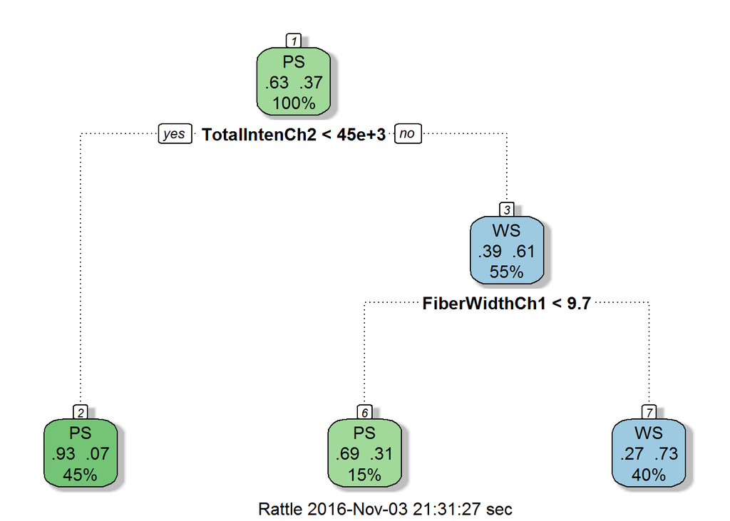

```r
library(AppliedPredictiveModeling)
data(segmentationOriginal)
library(caret)

#1
train <- subset(segmentationOriginal, Case=="Train")
test <- subset(segmentationOriginal, Case=="Test")

#2
set.seed(125)
mdl <- train(Class ~ ., method="rpart", data=train)
library(rattle)
fancyRpartPlot(mdl$finalModel)
```

```r
pd <- test[1:4,]
pd$TotalIntenCh2 <- c(23000,50000, 57000, NA)
pd$FiberWidthCh1 <- c(10,10,8, 8)
predict(mdl, newdata = pd)
```

```
## [1] PS WS PS
## Levels: PS WS
```

### Answer

1. PS
2. WS
3. PS
4. Not possible to predict

# Problem 2

If K is small in a K-fold cross validation is the bias in the estimate of out-of-sample (test set) accuracy smaller or bigger? If K is small is the variance in the estimate of out-of-sample (test set) accuracy smaller or bigger. Is K large or small in leave one out cross validation?

### Answer

- The bias is larger and the variance is smaller. Under leave one out cross validation K is equal to two.
- The bias is smaller and the variance is smaller. Under leave one out cross validation K is equal to one.
- The bias is smaller and the variance is bigger. Under leave one out cross validation K is equal to one.
- **The bias is larger and the variance is smaller. Under leave one out cross validation K is equal to the sample size.**

# Problem 3

These data contain information on 572 different Italian olive oils from multiple regions in Italy. Fit a classification tree where Area is the outcome variable. Then predict the value of area for the following data frame using the tree command with all defaults.

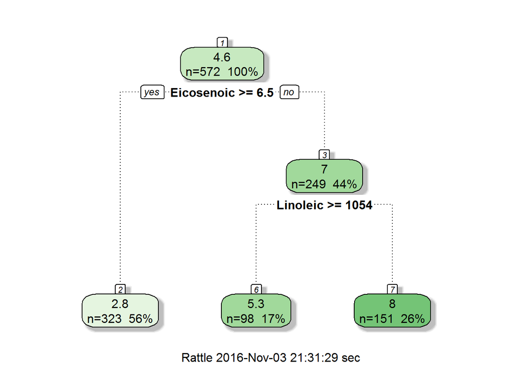

```r
library(pgmm)
data(olive)
olive = olive[,-1]

mdl2 <- train(Area ~ ., method="rpart", data=olive)
fancyRpartPlot(mdl2$finalModel)
```

```r
dat <- as.data.frame(t(colMeans(olive)))
predict(mdl2, newdata = dat)
```

```
##        1
## 2.783282
```

What is the resulting prediction? Is the resulting prediction strange? Why or why not?

### Answer

2.783. It is strange because Area should be a qualitative variable - but tree is reporting the average value of Area as a numeric variable in the leaf predicted for newdata

The confusing result stems from the fact that the *Area* variable is of the numeric class. Let’s convert it to a factor and run the same commands to see what happens.

[figure not shown]

```r
olive$Area <- factor(olive$Area)
mdl2.2 <- train(Area ~ ., method="rpart", data=olive)
fancyRpartPlot(mdl2.2$finalModel)
```

```r
predict(mdl2.2, newdata = dat)
```

```
## [1] 9
## Levels: 1 2 3 4 5 6 7 8 9
```

# Problem 4

Load the South Africa Heart Disease Data and create training and test sets with the following code:

```r
library(ElemStatLearn)
data(SAheart)
SAheart$chd <- factor(SAheart$chd)
set.seed(8484)
train = sample(1:dim(SAheart)[1],size=dim(SAheart)[1]/2,replace=F)
trainSA = SAheart[train,]
testSA = SAheart[-train,]
```

Then set the seed to 13234 and fit a logistic regression model (method=“glm”, be sure to specify family=“binomial”) with Coronary Heart Disease (chd) as the outcome and age at onset, current alcohol consumption, obesity levels, cumulative tabacco, type-A behavior, and low density lipoprotein cholesterol as predictors. Calculate the misclassification rate for your model using this function and a prediction on the “response” scale:

```r
set.seed(13234)
mdl4 <- train(chd ~ age + alcohol + obesity + tobacco + typea + ldl,
              method = "glm", family="binomial", data=trainSA)

missClass = function(values,prediction){sum(((prediction > 0.5)*1) != values)/length(values)}
# Training set misclassification rate
missClass(as.integer(trainSA$chd)-1, as.integer(predict(mdl4, trainSA))-1)
```

```
## [1] 0.2727273
```

```r
# Test set misclassification rate
missClass(as.integer(testSA$chd)-1, as.integer(predict(mdl4, testSA))-1)
```

```
## [1] 0.3116883
```

# Problem 5

Set the variable y to be a factor variable in both the training and test set. Then set the seed to 33833. Fit a random forest predictor relating the factor variable y to the remaining variables. Read about variable importance in random forests here: [LINK](http://www.stat.berkeley.edu/~breiman/RandomForests/cc_home.htm#ooberr) The caret package uses by default the Gini importance.

Calculate the variable importance using the varImp function in the caret package. What is the order of variable importance?

```r
library(ElemStatLearn)
data(vowel.train)
data(vowel.test)
vowel.test$y <- factor(vowel.test$y)
vowel.train$y <- factor(vowel.train$y)
set.seed(33833)

mdl5 <- train(y ~ ., method="rf", data = vowel.train)
varImp(mdl5)
```

```
## rf variable importance
##
##       Overall
## x.1  100.0000
## x.2   98.5960
## x.5   44.3214
## x.6   28.3926
## x.8   14.9865
## x.9    6.7483
## x.3    4.8055
## x.4    4.5061
## x.7    0.5042
## x.10   0.0000
```